# Reproducible Reserch Assignment 1

```r
knitr::opts_chunk$set(fig.path='figure/',
                      echo=TRUE, warning=FALSE, message=FALSE)
```

```r
activity <- read.csv("activity.csv")
activity <- na.omit(activity)
summary(activity)
```

```
##      steps                date          interval
##  Min.   :  0.00   2012-10-02:  288   Min.   :   0.0
##  1st Qu.:  0.00   2012-10-03:  288   1st Qu.: 588.8
##  Median :  0.00   2012-10-04:  288   Median :1177.5
##  Mean   : 37.38   2012-10-05:  288   Mean   :1177.5
##  3rd Qu.: 12.00   2012-10-06:  288   3rd Qu.:1766.2
##  Max.   :806.00   2012-10-07:  288   Max.   :2355.0
##                   (Other)   :13536
```

What is mean total number of steps taken per day?

Making a histogram of the total number of steps taken each day

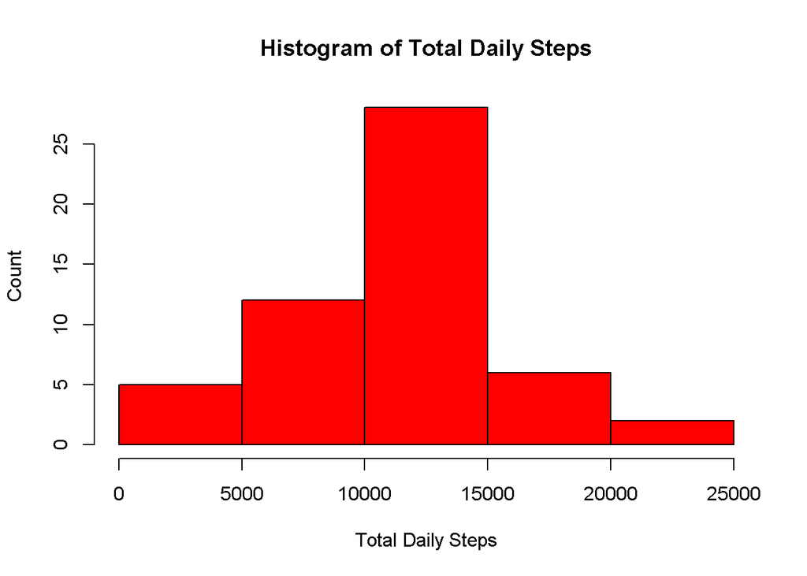

```r
library(dplyr)
activity$date <- as.Date(activity$date)
total_steps_day <- activity %>% group_by(date) %>% summarize(sum(steps))
hist(total_steps_day$`sum(steps)`, col="red", main="Histogram of Total Daily Steps", xlab="Total Daily Steps",ylab = "Count")
```

3. Mean and median number of steps taken each day Calculate and report the mean and median of the total number of steps taken per day

[output not shown]

[output not shown]

**The Mean number of steps taken each day is approximately 10766 steps.**

**The Median number of steps taken each day is approximately 10765 steps.**

What is the average daily activity pattern?

4. Time series plot of the average number of steps taken Make a time series plot (i.e. type = “l”) of the 5-minute interval (x-axis) and the average number of steps taken averaged across all days (y-axis)

Grouping data by date and interval and average number of steps

```r
Avg_steps_day_interval <- activity %>% group_by(date,interval) %>% summarize(mean(steps))
```

Grouping data by date and average number of steps

```r
Avg_steps_day <- activity %>% group_by(date) %>% summarize(mean(steps))
```

Grouping data by interval and average of steps

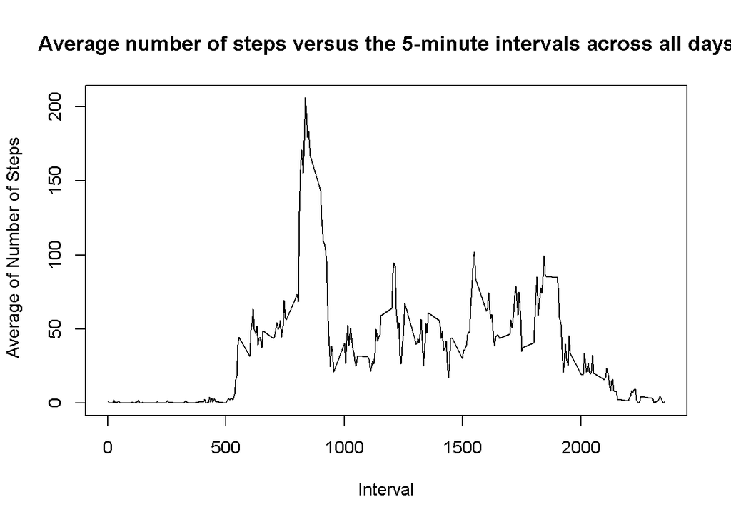

```r
Avg_steps_interval <- aggregate(steps ~ interval,FUN=mean,data = activity)

plot(Avg_steps_interval$interval, Avg_steps_interval$steps, type="l", ylab=" Average of Number of Steps", xlab="Interval",main= "Average number of steps versus the 5-minute intervals across all days")
```

5. The 5-minute interval that, on average, contains the maximum number of steps Which 5-minute interval, on average across all the days in the dataset, contains the maximum number of steps?

Finding the time block with maximum steps

```r
max_interval <- Avg_steps_interval[Avg_steps_interval$steps == max(Avg_steps_interval$steps),]
```

**The time interval with maximum number of steps which is approximately 206 is around 8:35 am.**

Imputing missing values 6) Code to describe and show a strategy for imputing missing data Imputing missing values Calculate and report the total number of missing values in the dataset

```r
activity <- read.csv("activity.csv")
summary(activity) # 2304  NA's in steps
```

```
##      steps                date          interval
##  Min.   :  0.00   2012-10-01:  288   Min.   :   0.0
##  1st Qu.:  0.00   2012-10-02:  288   1st Qu.: 588.8
##  Median :  0.00   2012-10-03:  288   Median :1177.5
##  Mean   : 37.38   2012-10-04:  288   Mean   :1177.5
##  3rd Qu.: 12.00   2012-10-05:  288   3rd Qu.:1766.2
##  Max.   :806.00   2012-10-06:  288   Max.   :2355.0
##  NA's   :2304     (Other)   :15840
```

Average of steps aggregated by interval

```r
Avg_steps_interval <- aggregate(steps ~ interval,FUN=mean,data = activity)
colnames(Avg_steps_interval) <- c("interval", "Avg steps")
```

Create a new dataset that is equal to the original dataset but with the missing data filled in. merging dataframes - activity and ‘average of steps aggregated by interval’ on interval

```r
activity_merged_interval <- merge(activity,Avg_steps_interval, by="interval", all.x=TRUE)
```

```r
activity_merged_interval$steps[is.na(activity_merged_interval$steps)] <- activity_merged_interval$`Avg steps`[is.na(activity_merged_interval$steps)]
summary(activity_merged_interval)
```

```
##     interval          steps                date         Avg steps
##  Min.   :   0.0   Min.   :  0.00   2012-10-01:  288   Min.   :  0.000
##  1st Qu.: 588.8   1st Qu.:  0.00   2012-10-02:  288   1st Qu.:  2.486
##  Median :1177.5   Median :  0.00   2012-10-03:  288   Median : 34.113
##  Mean   :1177.5   Mean   : 37.38   2012-10-04:  288   Mean   : 37.383
##  3rd Qu.:1766.2   3rd Qu.: 27.00   2012-10-05:  288   3rd Qu.: 52.835
##  Max.   :2355.0   Max.   :806.00   2012-10-06:  288   Max.   :206.170
##                                    (Other)   :15840
```

7. Histogram of the total number of steps taken each day after missing values are imputed

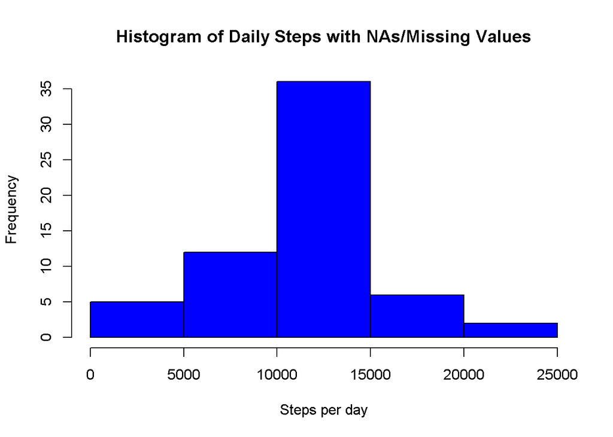

```r
total_steps_day_newdata <- activity_merged_interval %>% group_by(date) %>% summarize(sum(steps))
hist(total_steps_day_newdata$`sum(steps)`, col="blue", main="Histogram of Daily Steps with NAs/Missing Values", xlab="Steps per day")
```

```r
Avg_steps_day_newdata <- activity_merged_interval %>% group_by(date) %>% summarize(mean(steps))
Median_steps_day_newdata <- activity_merged_interval %>% group_by(date) %>% summarize(median(steps))
```

8. Panel plot comparing the average number of steps taken per 5-minute interval across weekdays and weekends Are there differences in activity patterns between weekdays and weekends?

creating a new column to mark day of week as per day creating new column to mark day of weeek as weekday or weekend

```r
library(lubridate)
activity_merged_interval$Day = wday(activity_merged_interval$date, label = TRUE)
activity_merged_interval$DayType <- "Weekday"
activity_merged_interval$DayType[which(activity_merged_interval$Day %in% c("Sat","Sun"))] <- "Weekend"


summary(activity_merged_interval)
```

```
##     interval          steps                date         Avg steps
##  Min.   :   0.0   Min.   :  0.00   2012-10-01:  288   Min.   :  0.000
##  1st Qu.: 588.8   1st Qu.:  0.00   2012-10-02:  288   1st Qu.:  2.486
##  Median :1177.5   Median :  0.00   2012-10-03:  288   Median : 34.113
##  Mean   :1177.5   Mean   : 37.38   2012-10-04:  288   Mean   : 37.383
##  3rd Qu.:1766.2   3rd Qu.: 27.00   2012-10-05:  288   3rd Qu.: 52.835
##  Max.   :2355.0   Max.   :806.00   2012-10-06:  288   Max.   :206.170
##                                    (Other)   :15840
##     Day         DayType
##  Sun  :2304   Length:17568
##  Mon  :2592   Class :character
##  Tues :2592   Mode  :character
##  Wed  :2592
##  Thurs:2592
##  Fri  :2592
##  Sat  :2304
```

```r
Avg_steps_daytype <- activity_merged_interval %>% group_by(DayType) %>% summarize(mean(steps))

Avg_steps_daytype_interval <- aggregate(steps ~ DayType + interval,FUN=mean,data = activity_merged_interval)
```

splitting this dataframe into two separate dataframes separated by DayType= Weekday/Weekend

```r
weekday_df <-subset(Avg_steps_daytype_interval,Avg_steps_daytype_interval$DayType=="Weekday")
weekend_df <-subset(Avg_steps_daytype_interval,Avg_steps_daytype_interval$DayType=="Weekend")
```

Making the plot

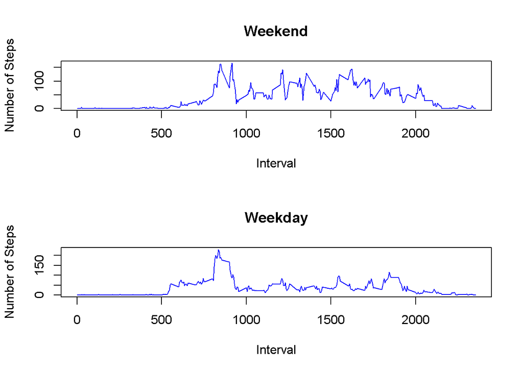

```r
par(mfrow = c(2, 1))
plot(weekend_df$interval,weekend_df$steps, type="l", ylab="Number of Steps", xlab="Interval", col="blue", main="Weekend")
plot(weekday_df$interval,weekday_df$steps, type="l", ylab="Number of Steps", xlab="Interval", col="blue",main="Weekday")
```

**So based on the plots above we can infer that there are differences in activity patterns between weekdays and weekends.**